# NLP_Project_Full_Code (2)

## **Problem Statement**

### Business Context

The prices of the stocks of companies listed under a global exchange are influenced by a variety of factors, with the company's financial performance, innovations and collaborations, and market sentiment being factors that play a significant role. News and media reports can rapidly affect investor perceptions and, consequently, stock prices in the highly competitive financial industry. With the sheer volume of news and opinions from a wide variety of sources, investors and financial analysts often struggle to stay updated and accurately interpret its impact on the market. As a result, investment firms need sophisticated tools to analyze market sentiment and integrate this information into their investment strategies.

### Problem Definition

With an ever-rising number of news articles and opinions, an investment startup aims to leverage artificial intelligence to address the challenge of interpreting stock-related news and its impact on stock prices. They have collected historical daily news for a specific company listed under NASDAQ, along with data on its daily stock price and trade volumes.

As a member of the Data Science and AI team in the startup, you have been tasked with analyzing the data, developing an AI-driven sentiment analysis system that will automatically process and analyze news articles to gauge market sentiment, and summarizing the news at a weekly level to enhance the accuracy of their stock price predictions and optimize investment strategies. This will empower their financial analysts with actionable insights, leading to more informed investment decisions and improved client outcomes.

### Data Dictionary

- `Date` : The date the news was released
- `News` : The content of news articles that could potentially affect the company's stock price
- `Open` : The stock price (in \$) at the beginning of the day
- `High` : The highest stock price (in \$) reached during the day
- `Low` : The lowest stock price (in \$) reached during the day
- `Close` : The adjusted stock price (in \$) at the end of the day
- `Volume` : The number of shares traded during the day
- `Label` : The sentiment polarity of the news content
  - 1: positive
  - 0: neutral
  - -1: negative

## **Installing and Importing Necessary Libraries**

```python
# installing the sentence-transformers and gensim libraries for word embeddings
!pip install -U sentence-transformers gensim transformers tqdm -q
```

```
     ━━━━━━━━━━━━━━━━━━━━━━━━━━━━━━━━━━━━━━━━ 44.1/44.1 kB 2.6 MB/s eta 0:00:00
     ━━━━━━━━━━━━━━━━━━━━━━━━━━━━━━━━━━━━━━━━ 57.6/57.6 kB 3.7 MB/s eta 0:00:00
   ━━━━━━━━━━━━━━━━━━━━━━━━━━━━━━━━━━━━━━━━ 268.8/268.8 kB 12.2 MB/s eta 0:00:00
   ━━━━━━━━━━━━━━━━━━━━━━━━━━━━━━━━━━━━━━━━ 10.0/10.0 MB 105.2 MB/s eta 0:00:00
   ━━━━━━━━━━━━━━━━━━━━━━━━━━━━━━━━━━━━━━━━ 78.6/78.6 kB 5.2 MB/s eta 0:00:00
```

```python
# To manipulate and analyze data
import pandas as pd
import numpy as np

# To visualize data
import matplotlib.pyplot as plt
import seaborn as sns

# To used time-related functions
import time

# To parse JSON data
import json

# To build, tune, and evaluate ML models
from sklearn.tree import DecisionTreeClassifier
from sklearn.ensemble import GradientBoostingClassifier
from sklearn.ensemble import RandomForestClassifier

from sklearn.model_selection import GridSearchCV
from sklearn.metrics import confusion_matrix, accuracy_score, f1_score, precision_score, recall_score

# To load/create word embeddings
from gensim.models import Word2Vec
from gensim.models import KeyedVectors
from gensim.scripts.glove2word2vec import glove2word2vec

# To work with transformer models
import torch
from sentence_transformers import SentenceTransformer

# To implement progress bar related functionalities
from tqdm import tqdm
tqdm.pandas()

# To ignore unnecessary warnings
import warnings
warnings.filterwarnings('ignore')
```

## **Loading the dataset**

```python
from google.colab import drive
drive.mount('/content/drive')
```

```python
stock_news = pd.read_csv("/content/drive/MyDrive/finalProject/stock_news.csv")
```

```python
stock = stock_news.copy()
```

## **Data Overview**

```python
stock.head()
```

|  | Date | News | Open | High | Low | Close | Volume | Label |
| --- | --- | --- | --- | --- | --- | --- | --- | --- |
| 0 | 2019-01-02 | The tech sector experienced a significant dec... | 41.740002 | 42.244999 | 41.482498 | 40.246914 | 130672400 | -1 |
| 1 | 2019-01-02 | Apple lowered its fiscal Q1 revenue guidance ... | 41.740002 | 42.244999 | 41.482498 | 40.246914 | 130672400 | -1 |
| 2 | 2019-01-02 | Apple cut its fiscal first quarter revenue fo... | 41.740002 | 42.244999 | 41.482498 | 40.246914 | 130672400 | -1 |
| 3 | 2019-01-02 | This news article reports that yields on long... | 41.740002 | 42.244999 | 41.482498 | 40.246914 | 130672400 | -1 |
| 4 | 2019-01-02 | Apple's revenue warning led to a decline in U... | 41.740002 | 42.244999 | 41.482498 | 40.246914 | 130672400 | -1 |

```python
stock.shape
```

```
(349, 8)
```

```python
#check the data types
stock.info()
```

```
<class 'pandas.core.frame.DataFrame'>
RangeIndex: 349 entries, 0 to 348
Data columns (total 8 columns):
 #   Column  Non-Null Count  Dtype
---  ------  --------------  -----
 0   Date    349 non-null    object
 1   News    349 non-null    object
 2   Open    349 non-null    float64
 3   High    349 non-null    float64
 4   Low     349 non-null    float64
 5   Close   349 non-null    float64
 6   Volume  349 non-null    int64
 7   Label   349 non-null    int64
dtypes: float64(4), int64(2), object(2)
memory usage: 21.9+ KB
```

```python
stock['Date'] = pd.to_datetime(stock['Date'])  # to convert the 'Date' column in the 'stock' DataFrame to datetime format.
```

```python
stock.tail()
```

|  | Date | News | Open | High | Low | Close | Volume | Label |
| --- | --- | --- | --- | --- | --- | --- | --- | --- |
| 344 | 2019-04-30 | Media mogul Oprah Winfrey, known for influenc... | 50.764999 | 50.849998 | 49.7775 | 48.70879 | 186139600 | -1 |
| 345 | 2019-04-30 | European shares fell on Tuesday, with banks u... | 50.764999 | 50.849998 | 49.7775 | 48.70879 | 186139600 | -1 |
| 346 | 2019-04-30 | This article reports that the S&P 500 reached... | 50.764999 | 50.849998 | 49.7775 | 48.70879 | 186139600 | -1 |
| 347 | 2019-04-30 | The Federal Reserve is anticipated to keep in... | 50.764999 | 50.849998 | 49.7775 | 48.70879 | 186139600 | -1 |
| 348 | 2019-04-30 | In the first quarter, South Korea's Samsung E... | 50.764999 | 50.849998 | 49.7775 | 48.70879 | 186139600 | 0 |

```python
# statistical summary
stock.describe().T
```

|  | count | mean | min | 25% | 50% | 75% | max | std |
| --- | --- | --- | --- | --- | --- | --- | --- | --- |
| Date | 349 | 2019-02-16 16:05:30.085959936 | 2019-01-02 00:00:00 | 2019-01-14 00:00:00 | 2019-02-05 00:00:00 | 2019-03-22 00:00:00 | 2019-04-30 00:00:00 | NaN |
| Open | 349.0 | 46.229233 | 37.567501 | 41.740002 | 45.974998 | 50.7075 | 66.817497 | 6.442817 |
| High | 349.0 | 46.700458 | 37.817501 | 42.244999 | 46.025002 | 50.849998 | 67.0625 | 6.507321 |
| Low | 349.0 | 45.745394 | 37.305 | 41.482498 | 45.639999 | 49.7775 | 65.862503 | 6.391976 |
| Close | 349.0 | 44.926317 | 36.254131 | 40.246914 | 44.596924 | 49.11079 | 64.805229 | 6.398338 |
| Volume | 349.0 | 128948236.103152 | 45448000.0 | 103272000.0 | 115627200.0 | 151125200.0 | 244439200.0 | 43170314.918964 |
| Label | 349.0 | -0.054441 | -1.0 | -1.0 | 0.0 | 0.0 | 1.0 | 0.715119 |

```python
#check the duplicate values
stock.duplicated().sum()
```

```
0
```

## **Exploratory Data Analysis**

### Univariate Analysis

- Distribution of individual variables
- Compute and check the distribution of the length of news content

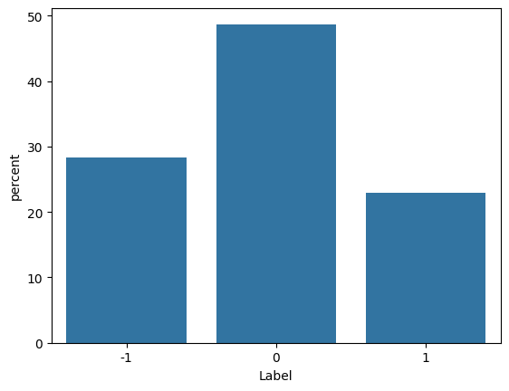

```python
sns.countplot(data=stock, x="Label", stat="percent")
```

- The sentiment is mostly neutral

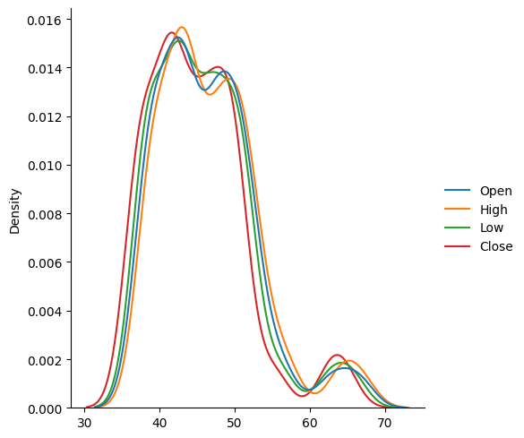

```python
sns.displot(data=stock[["Open","High","Low","Close"]], kind="kde", palette="tab10")
```

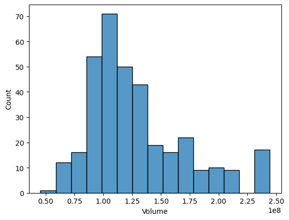

```python
sns.histplot(stock, x='Volume')
```

```python
#Total number of words present in the news content.
stock['news_len'] = stock['News'].apply(lambda x: len(x.split(' ')))


stock['news_len'].describe()  #statistical summary for the news content length
```

|  | news_len |
| --- | --- |
| count | 349.000000 |
| mean | 49.312321 |
| std | 5.727770 |
| min | 19.000000 |
| 25% | 46.000000 |
| 50% | 50.000000 |
| 75% | 53.000000 |
| max | 61.000000 |

**dtype:** float64

### Bivariate Analysis

- Correlation
- Sentiment Polarity vs Price
- Date vs Price

**Note**: The above points are listed to provide guidance on how to approach bivariate analysis. Analysis has to be done beyond the above listed points to get maximum scores.

#### Correlation

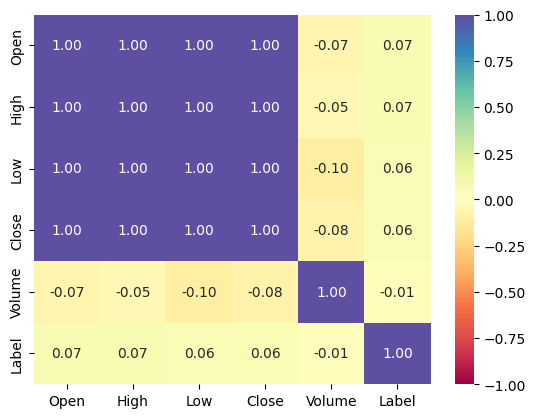

```python
#correlation matrix for numeric columns only.
sns.heatmap(
    stock[stock.select_dtypes(include=np.number).columns].corr(), annot=True, vmin=-1, vmax=1, fmt=".2f", cmap="Spectral"
);
```

- Close, Low, High and Open show a high correlation as it may indicate the values didnt changed much during the period of time.

#### Label vs Price (Open, High, Low, Close)

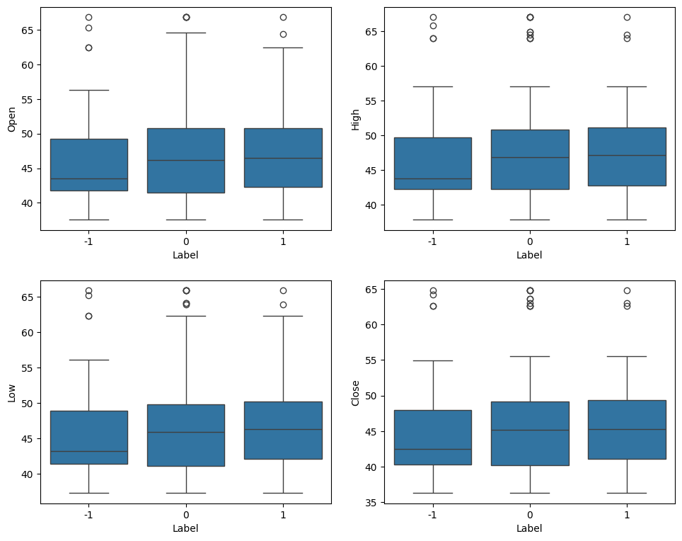

```python
plt.figure(figsize=(10, 8))

for i, variable in enumerate(['Open', 'High', 'Low', 'Close']):
    plt.subplot(2, 2, i + 1)
    sns.boxplot(data=stock, x="Label", y=variable)
    plt.tight_layout(pad=2)

plt.show()
```

- Neutral and positive sentiments are the stocks with higher pricer

#### Label vs Volume

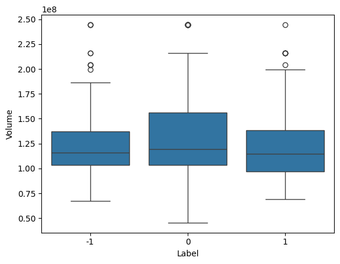

```python
# boxplot of Label vs Volume
sns.boxplot(
    data=stock, x="Label", y="Volume"
);
```

#### Date vs Price (Open, High, Low, Close)

```python
stock_daily = stock.groupby('Date').agg(
    {
        'Open': 'mean',
        'High': 'mean',
        'Low': 'mean',
        'Close': 'mean',
        'Volume': 'mean',
    }
).reset_index()  # Group the 'stocks' DataFrame by the 'Date' column

stock_daily.set_index('Date', inplace=True)
stock_daily.head()
```

| Date | Open | High | Low | Close | Volume |
| --- | --- | --- | --- | --- | --- |
| 2019-01-02 | 41.740002 | 42.244999 | 41.482498 | 40.246914 | 130672400.0 |
| 2019-01-03 | 43.570000 | 43.787498 | 43.222500 | 42.470604 | 103544800.0 |
| 2019-01-04 | 47.910000 | 47.919998 | 47.095001 | 46.419842 | 111448000.0 |
| 2019-01-07 | 50.792500 | 51.122501 | 50.162498 | 49.110790 | 109012000.0 |
| 2019-01-08 | 53.474998 | 54.507500 | 51.685001 | 50.787209 | 216071600.0 |

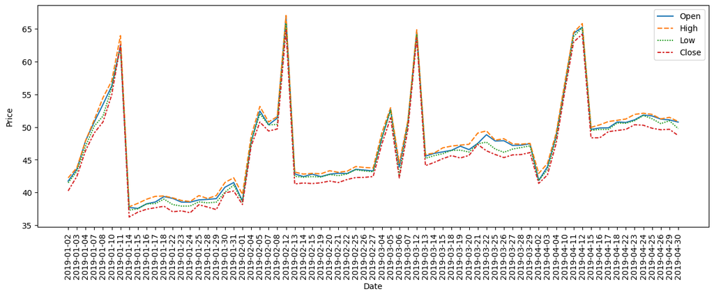

```python
plt.figure(figsize=(15,5))
plt.xticks(rotation=90)
plt.ylabel('Price',rotation=90, fontsize=10, labelpad=10)
sns.lineplot(stock_daily.drop("Volume", axis=1));
```

#### Volume vs Close Price

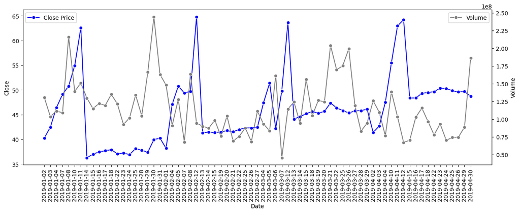

```python
# Create a figure and axis
fig, ax1 = plt.subplots(figsize=(15,5))
plt.xticks(rotation=90)

# Lineplot on primary y-axis
sns.lineplot(data=stock_daily.reset_index(), x='Date', y='Close', ax=ax1, color='blue', marker='o', label='Close Price')

# Create a secondary y-axis
ax2 = ax1.twinx()

# Lineplot on secondary y-axis
sns.lineplot(data=stock_daily.reset_index(), x='Date', y='Volume', ax=ax2, color='gray', marker='o', label='Volume')

ax1.legend(bbox_to_anchor=(0.12,1));
```

## **Data Preprocessing**

```python
stock["Date"].describe()
```

|  | Date |
| --- | --- |
| count | 349 |
| unique | 71 |
| top | 2019-01-03 |
| freq | 28 |

**dtype:** object

### Train-test-validation Split

```python
#rows where the 'Date' is before '2019-04-01'
X_train = stock[(stock['Date'] < '2019-04-01')].reset_index()
#rows where the 'Date' is from '2019-04-01 to '2019-04-16' (excluded)
X_val = stock[(stock['Date'] >= '2019-04-01') & (stock['Date'] < '2019-04-16')].reset_index()
#rows where the 'Date' is from '2019-04-16' till the end.
X_test = stock[stock['Date'] >= '2019-04-16'].reset_index()
```

```python
#'Label' column as the target variable
y_train = X_train["Label"].copy()
y_val = X_val["Label"].copy()
y_test = X_test["Label"].copy()
```

```python
print("Train data shape",X_train.shape)
print("Validation data shape",X_val.shape)
print("Test data shape ",X_test.shape)

print("Train label shape",y_train.shape)
print("Validation label shape",y_val.shape)
print("Test label shape ",y_test.shape)
```

```
Train data shape (286, 9)
Validation data shape (21, 9)
Test data shape  (42, 9)
Train label shape (286,)
Validation label shape (21,)
Test label shape  (42,)
```

## **Word Embeddings**

### Word2Vec

```python
# Creating a list of all words in our data
words_list = [item.split(" ") for item in stock['News'].values]
```

```python
# Creating an instance of Word2Vec
vec_size = 300
model_W2V = Word2Vec(words_list, vector_size = vec_size, min_count = 1, window=5, workers = 6)
```

```python
# Checking the size of the vocabulary
print("Length of the vocabulary is", len(list(model_W2V.wv.key_to_index)))
```

```
Length of the vocabulary is 4682
```

```python
# Checking the word embedding of a random word
word = "crash"
model_W2V.wv[word]
```

[output not shown]

[output cut: 21 more lines]

[output not shown]

```python
# Checking the word embedding of a random word
word = "increase"
model_W2V.wv[word]
```

[output not shown]

[output cut: 21 more lines]

[output not shown]

```python
# Retrieving the words present in the Word2Vec model's vocabulary
words = list(model_W2V.wv.key_to_index.keys())

# Retrieving word vectors for all the words present in the model's vocabulary
wvs = model_W2V.wv[words].tolist()

# Creating a dictionary of words and their corresponding vectors
word_vector_dict = dict(zip(words, wvs))
```

```python
def average_vectorizer_Word2Vec(doc):
    # Initializing a feature vector for the sentence
    feature_vector = np.zeros((vec_size,), dtype="float64")

    # Creating a list of words in the sentence that are present in the model vocabulary
    words_in_vocab = [word for word in doc.split() if word in words]

    # adding the vector representations of the words
    for word in words_in_vocab:
        feature_vector += np.array(word_vector_dict[word])

    # Dividing by the number of words to get the average vector
    if len(words_in_vocab) != 0:
        feature_vector /= len(words_in_vocab)

    return feature_vector
```

```python
# creating a dataframe of the vectorized documents
start = time.time()

X_train_wv = pd.DataFrame(X_train["News"].apply(average_vectorizer_Word2Vec).tolist(), columns=['Feature '+str(i) for i in range(vec_size)])
X_val_wv = pd.DataFrame(X_val["News"].apply(average_vectorizer_Word2Vec).tolist(), columns=['Feature '+str(i) for i in range(vec_size)])
X_test_wv = pd.DataFrame(X_test["News"].apply(average_vectorizer_Word2Vec).tolist(), columns=['Feature '+str(i) for i in range(vec_size)])

end = time.time()
print('Time taken ', (end-start))
```

```
Time taken  0.49344563484191895
```

```python
print(X_train_wv.shape, X_val_wv.shape, X_test_wv.shape)
```

```
(286, 300) (21, 300) (42, 300)
```

### GloVe

```python
# load the Stanford GloVe model
filename = '/content/drive/MyDrive/finalProject/glove.6B.100d.txt.word2vec'
glove_model = KeyedVectors.load_word2vec_format(filename, binary=False)
```

```python
# Checking the size of the vocabulary
print("Length of the vocabulary is", len(glove_model.index_to_key))
```

```
Length of the vocabulary is 400000
```

```python
# Checking the word embedding of a random word
word = "rocket"
glove_model[word]
```

```
array([-0.7589  , -0.048517, -0.3419  ,  0.43569 , -0.26149 , -0.41701 ,
        1.4197  ,  0.071032,  0.19189 ,  1.7343  , -0.075066, -0.3844  ,
        0.72982 ,  0.43115 ,  0.014872, -0.15949 , -0.47488 ,  0.54407 ,
       -0.51206 ,  0.45661 ,  0.91531 , -0.53997 , -0.56571 ,  0.44308 ,
        0.46003 ,  0.93335 , -0.8411  ,  0.58144 ,  0.24748 ,  0.37628 ,
       -0.44456 ,  0.018038, -0.6738  ,  0.53414 ,  0.33857 , -0.58096 ,
        0.22982 , -0.18467 ,  0.47815 ,  0.26848 , -0.60577 ,  0.058895,
       -0.14668 ,  0.48053 ,  0.71319 , -0.36659 , -0.096911,  0.65809 ,
       -0.1794  ,  0.12878 , -0.11663 ,  0.70197 ,  0.18391 ,  0.9595  ,
        0.39391 , -1.8271  , -0.21619 ,  0.50707 ,  1.2413  ,  0.29833 ,
        0.49957 ,  0.46483 ,  0.52288 ,  1.4425  , -0.076159,  0.78259 ,
        0.56248 ,  0.04076 , -0.86032 ,  0.023794,  0.28679 , -0.8865  ,
       -0.15278 , -0.28923 , -0.48499 ,  0.16892 ,  0.8951  ,  0.34617 ,
       -1.5552  , -0.12431 ,  0.92213 ,  0.11942 , -0.72065 , -0.15417 ,
       -0.44404 ,  0.020276,  0.78977 , -0.18025 ,  0.27795 , -0.031635,
        0.024725,  1.1255  ,  0.15172 ,  0.50362 , -0.3334  ,  0.46577 ,
       -0.34179 ,  0.51168 ,  0.92858 , -0.22453 ], dtype=float32)
```

```python
# Checking the word embedding of a random word
word = "green"
glove_model[word]
```

```
array([-6.7907e-01,  3.4908e-01, -2.3984e-01, -9.9652e-01,  7.3782e-01,
       -6.5911e-04,  2.8010e-01,  1.7287e-02, -3.6063e-01,  3.6955e-02,
       -4.0395e-01,  2.4092e-02,  2.8958e-01,  4.0497e-01,  6.9992e-01,
        2.5269e-01,  8.0350e-01,  4.9370e-02,  1.5562e-01, -6.3286e-03,
       -2.9414e-01,  1.4728e-01,  1.8977e-01, -5.1791e-01,  3.6986e-01,
        7.4582e-01,  8.2689e-02, -7.2601e-01, -4.0939e-01, -9.7822e-02,
       -1.4096e-01,  7.1121e-01,  6.1933e-01, -2.5014e-01,  4.2250e-01,
        4.8458e-01, -5.1915e-01,  7.7125e-01,  3.6685e-01,  4.9652e-01,
       -4.1298e-02, -1.4683e+00,  2.0038e-01,  1.8591e-01,  4.9860e-02,
       -1.7523e-01, -3.5528e-01,  9.4153e-01, -1.1898e-01, -5.1903e-01,
       -1.1887e-02, -3.9186e-01, -1.7479e-01,  9.3451e-01, -5.8931e-01,
       -2.7701e+00,  3.4522e-01,  8.6533e-01,  1.0808e+00, -1.0291e-01,
       -9.1220e-02,  5.5092e-01, -3.9473e-01,  5.3676e-01,  1.0383e+00,
       -4.0658e-01,  2.4590e-01, -2.6797e-01, -2.6036e-01, -1.4151e-01,
       -1.2022e-01,  1.6234e-01, -7.4320e-01, -6.4728e-01,  4.7133e-02,
        5.1642e-01,  1.9898e-01,  2.3919e-01,  1.2550e-01,  2.2471e-01,
        8.2613e-01,  7.8328e-02, -5.7020e-01,  2.3934e-02, -1.5410e-01,
       -2.5739e-01,  4.1262e-01, -4.6967e-01,  8.7914e-01,  7.2629e-01,
        5.3862e-02, -1.1575e+00, -4.7835e-01,  2.0139e-01, -1.0051e+00,
        1.1515e-01, -9.6609e-01,  1.2960e-01,  1.8388e-01, -3.0383e-02],
      dtype=float32)
```

```python
# Retrieving the words present in the GloVe model's vocabulary
glove_words = glove_model.index_to_key

# Creating a dictionary of words and their corresponding vectors
glove_word_vector_dict = dict(zip(glove_model.index_to_key,list(glove_model.vectors)))
```

```python
vec_size=100
def average_vectorizer_GloVe(doc):
    # Initializing a feature vector for the sentence
    feature_vector = np.zeros((vec_size,), dtype="float64")

    # Creating a list of words in the sentence that are present in the model vocabulary
    words_in_vocab = [word for word in doc.split() if word in glove_words]

    # adding the vector representations of the words
    for word in words_in_vocab:
        feature_vector += np.array(glove_word_vector_dict[word])

    # Dividing by the number of words to get the average vector
    if len(words_in_vocab) != 0:
        feature_vector /= len(words_in_vocab)

    return feature_vector
```

```python
# creating a dataframe of the vectorized documents
start = time.time()
#apply GloVe on 'News' column
X_train_gl = pd.DataFrame(X_train["News"].apply(average_vectorizer_GloVe).tolist(), columns=['Feature '+str(i) for i in range(vec_size)])
X_val_gl = pd.DataFrame(X_val["News"].apply(average_vectorizer_GloVe).tolist(), columns=['Feature '+str(i) for i in range(vec_size)])
X_test_gl = pd.DataFrame(X_test["News"].apply(average_vectorizer_GloVe).tolist(), columns=['Feature '+str(i) for i in range(vec_size)])

end = time.time()
print('Time taken ', (end-start))
```

```
Time taken  31.288712978363037
```

```python
print(X_train_gl.shape, X_val_gl.shape, X_test_gl.shape)
```

```
(286, 100) (21, 100) (42, 100)
```

### Sentence Transformer

#### Defining the model

```python
#Defining the model
model = SentenceTransformer('sentence-transformers/all-MiniLM-L6-v2')
```

#### Encoding the dataset

```python
# setting the device to GPU if available, else CPU
device = torch.device("cuda" if torch.cuda.is_available() else "cpu")
```

```python
# encoding the dataset
start = time.time()

#apply Sentence Transformer on 'News' column
X_train_st = model.encode(X_train["News"].values, show_progress_bar=True, device=device)
X_val_st = model.encode(X_val["News"].values, show_progress_bar=True, device=device)
X_test_st = model.encode(X_test["News"].values, show_progress_bar=True, device=device)

end = time.time()
print("Time taken ",(end-start))
```

```
Time taken  1.6505374908447266
```

## **Sentiment Analysis**

### Utility Functions

```python
def plot_confusion_matrix(model, predictors, target):
    """
    Plot a confusion matrix to visualize the performance of a classification model.

    Parameters:
    actual (array-like): The true labels.
    predicted (array-like): The predicted labels from the model.

    Returns:
    None: Displays the confusion matrix plot.
    """
    pred = model.predict(predictors)  # Make predictions using the classifier.

    cm = confusion_matrix(target, pred)  # Compute the confusion matrix.

    plt.figure(figsize=(5, 4))  # Create a new figure with a specified size.
    label_list = [0, 1,-1]  # Define the labels for the confusion matrix.
    sns.heatmap(cm, annot=True, fmt='.0f', cmap='Blues', xticklabels=label_list, yticklabels=label_list)
    # Plot the confusion matrix using a heatmap with annotations.

    plt.ylabel('Actual')  # Label for the y-axis.
    plt.xlabel('Predicted')  # Label for the x-axis.
    plt.title('Confusion Matrix')  # Title of the plot.
    plt.show()  # Display the plot.
```

```python
def model_performance_classification_sklearn(model, predictors, target):
    """
    Compute various performance metrics for a classification model using sklearn.

    Parameters:
    model (sklearn classifier): The classification model to evaluate.
    predictors (array-like): The independent variables used for predictions.
    target (array-like): The true labels for the dependent variable.

    Returns:
    pandas.DataFrame: A DataFrame containing the computed metrics (Accuracy, Recall, Precision, F1-score).
    """
    pred = model.predict(predictors)  # Make predictions using the classifier.

    acc = accuracy_score(target, pred)  # Compute Accuracy.
    recall = recall_score(target, pred,average='weighted')  # Compute Recall.
    precision = precision_score(target, pred,average='weighted')  # Compute Precision.
    f1 = f1_score(target, pred,average='weighted')  # Compute F1-score.

    # Create a DataFrame to store the computed metrics.
    df_perf = pd.DataFrame(
        {
            "Accuracy": [acc],
            "Recall": [recall],
            "Precision": [precision],
            "F1": [f1],
        }
    )

    return df_perf  # Return the DataFrame with the metrics.
```

### Base Model - Word2Vec

```python
# Building the model

#Uncomment only one of the snippets related to fitting the model to the data

base_wv = GradientBoostingClassifier(random_state = 42)
#base_wv = RandomForestClassifier(random_state=42)
#base_wv = DecisionTreeClassifier(random_state=42)

# Fitting on train data
base_wv.fit(X_train_wv, y_train)
```

```
GradientBoostingClassifier(random_state=42)
```

```python
plot_confusion_matrix(base_wv,X_train_wv,y_train)
```

[output not shown]

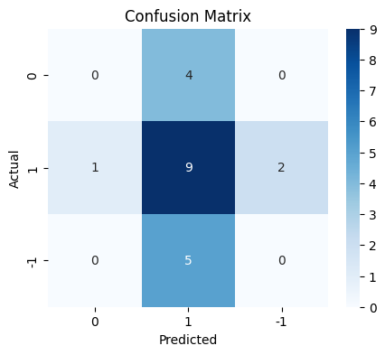

```python
plot_confusion_matrix(base_wv,X_val_wv,y_val)
```

```python
#Calculating different metrics on training data
base_train_wv = model_performance_classification_sklearn(base_wv,X_train_wv,y_train)
print("Training performance:\n", base_train_wv)
```

```
Training performance:
    Accuracy  Recall  Precision   F1
0       1.0     1.0        1.0  1.0
```

```python
#Calculating different metrics on validation data
base_val_wv = model_performance_classification_sklearn(base_wv,X_val_wv,y_val)
print("Validation performance:\n",base_val_wv)
```

```
Validation performance:
    Accuracy    Recall  Precision        F1
0  0.428571  0.428571   0.285714  0.342857
```

### Base Model - GloVe

```python
#Building the model

#Uncomment only one of the snippets related to fitting the model to the data

base_wv = GradientBoostingClassifier(random_state = 42)
#base_wv = RandomForestClassifier(random_state=42)
#base_wv = DecisionTreeClassifier(random_state=42)

# Fitting on train data
base_wv.fit(X_train_gl, y_train) #fit the chosen model on the train data
```

```
GradientBoostingClassifier(random_state=42)
```

```python
plot_confusion_matrix(base_wv,X_train_gl, y_train) #confusion matrix for the train data
```

[output not shown]

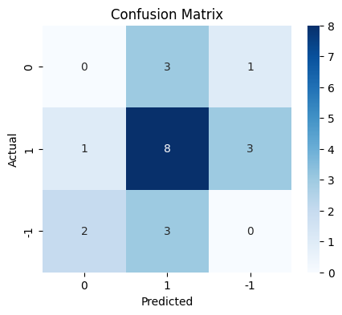

```python
plot_confusion_matrix(base_wv,X_val_gl, y_val) #confusion matrix for the validation data
```

```python
#Calculating different metrics on training data
base_train_gl=model_performance_classification_sklearn(base_wv,X_train_gl, y_train) #model performance for the training data
print("Training performance:\n", base_train_gl)
```

```
Training performance:
    Accuracy  Recall  Precision   F1
0       1.0     1.0        1.0  1.0
```

```python
#Calculating different metrics on validation data
base_val_gl = model_performance_classification_sklearn(base_wv,X_val_gl, y_val) #model performance for the validation data
print("Validation performance:\n",base_val_gl)
```

```
Validation performance:
    Accuracy    Recall  Precision        F1
0  0.380952  0.380952   0.326531  0.351648
```

### Base Model - Sentence Transformer

```python
# Building the model

#Uncomment only one of the snippets related to fitting the model to the data

base_wv = GradientBoostingClassifier(random_state = 42)
#base_wv = RandomForestClassifier(random_state=42)
#base_wv = DecisionTreeClassifier(random_state=42)

# Fitting on train data
base_wv.fit(X_train_st, y_train) #fit the chosen model on the train data
```

```
GradientBoostingClassifier(random_state=42)
```

```python
plot_confusion_matrix(base_wv,X_train_st, y_train) #confusion matrix for the train data
```

[output not shown]

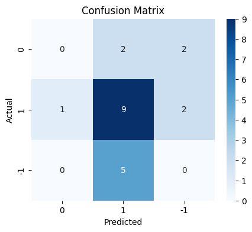

```python
plot_confusion_matrix(base_wv,X_val_st, y_val) #confusion matrix for the validation data
```

```python
#Calculating different metrics on training data
base_train_st=model_performance_classification_sklearn(base_wv,X_train_st, y_train) #model performance for the training data
print("Training performance:\n", base_train_st)
```

```
Training performance:
    Accuracy  Recall  Precision   F1
0       1.0     1.0        1.0  1.0
```

```python
#Calculating different metrics on validation data
base_val_st = model_performance_classification_sklearn(base_wv,X_val_st, y_val) #model performance for the validation data
print("Validation performance:\n",base_val_st)
```

```
Validation performance:
    Accuracy    Recall  Precision        F1
0  0.428571  0.428571   0.321429  0.367347
```

### Tuned Model - Word2Vec

```python
start = time.time()

# Choose the type of classifier.

#Uncomment only one of the snippets corrrsponding to the base model trained previously

tuned_wv = GradientBoostingClassifier(random_state = 42)
#tuned_wv = RandomForestClassifier(random_state=42)
#tuned_wv = DecisionTreeClassifier(random_state=42)


parameters = {
    'max_depth': np.arange(3,7),
    'min_samples_split': np.arange(5,12,2),
    'max_features': ['log2', 'sqrt', 0.2, 0.4]
}

# Run the grid search
grid_obj = GridSearchCV(tuned_wv, parameters, scoring='f1_weighted',cv=5,n_jobs=-1)
grid_obj = grid_obj.fit(X_train_wv, y_train)

end = time.time()
print("Time taken ",(end-start))

# Set the clf to the best combination of parameters
tuned_wv = grid_obj.best_estimator_
```

```
Time taken  542.9413914680481
```

```python
# Fit the best algorithm to the data.
tuned_wv.fit(X_train_wv, y_train)
```

```
GradientBoostingClassifier(max_features=0.4, min_samples_split=7,
                           random_state=42)
```

```python
plot_confusion_matrix(tuned_wv,X_train_wv,y_train)
```

[output not shown]

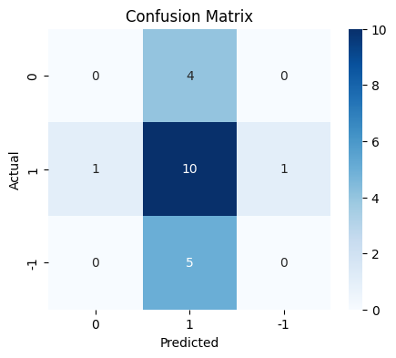

```python
plot_confusion_matrix(tuned_wv,X_val_wv,y_val)
```

```python
#Calculating different metrics on training data
tuned_train_wv=model_performance_classification_sklearn(tuned_wv,X_train_wv,y_train)
print("Training performance:\n",tuned_train_wv)
```

```
Training performance:
    Accuracy  Recall  Precision   F1
0       1.0     1.0        1.0  1.0
```

```python
#Calculating different metrics on validation data
tuned_val_wv = model_performance_classification_sklearn(tuned_wv,X_val_wv,y_val)
print("Validation performance:\n",tuned_val_wv)
```

```
Validation performance:
    Accuracy   Recall  Precision        F1
0   0.47619  0.47619   0.300752  0.368664
```

```python
start = time.time()

#Uncomment only one of the snippets corrrsponding to the base model trained previously

tuned_wv = GradientBoostingClassifier(random_state = 42)
#tuned_wv = RandomForestClassifier(random_state=42)
#tuned_wv = DecisionTreeClassifier(random_state=42)

parameters = {
    'max_depth': np.arange(3,7),
    'min_samples_split': np.arange(5,12,2),
    'max_features': ['log2', 'sqrt', 0.2, 0.4]
}

# Run the grid search
grid_obj = GridSearchCV(tuned_wv, parameters, scoring='f1_weighted',cv=5,n_jobs=-1) #pass the chosen model
grid_obj = grid_obj.fit(X_train_gl, y_train)

end = time.time()
print("Time taken ",(end-start))

# Set the clf to the best combination of parameters
tuned_gl = grid_obj.best_estimator_
```

```
Time taken  370.9410791397095
```

```python
# Fit the best algorithm to the data.
tuned_wv.fit(X_train_gl, y_train) #fit the chosen model on the train data
```

```
GradientBoostingClassifier(random_state=42)
```

```python
plot_confusion_matrix(tuned_wv,X_train_gl, y_train) #plot the confusion matrix for the train data
```

[output not shown]

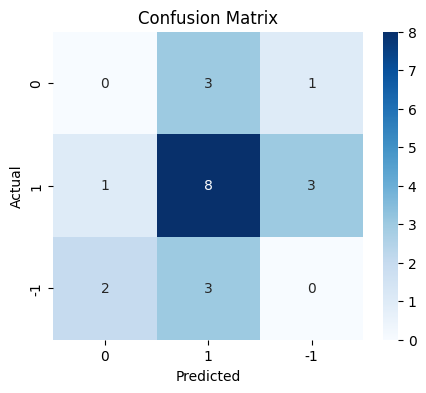

```python
plot_confusion_matrix(tuned_wv,X_val_gl, y_val) #plot the confusion matrix for the validation data
```

```python
#Calculating different metrics on training data
tuned_train_gl=model_performance_classification_sklearn(tuned_wv,X_train_gl, y_train)
print("Training performance:\n",tuned_train_gl)
```

```
Training performance:
    Accuracy  Recall  Precision   F1
0       1.0     1.0        1.0  1.0
```

```python
#Calculating different metrics on validation data
tuned_val_gl = model_performance_classification_sklearn(tuned_wv,X_val_gl, y_val)
print("Validation performance:\n",tuned_val_gl)
```

```
Validation performance:
    Accuracy    Recall  Precision        F1
0  0.380952  0.380952   0.326531  0.351648
```

```python
start = time.time()

# Choose the type of classifier.

#Uncomment only one of the snippets corrrsponding to the base model trained previously

tuned_wv = GradientBoostingClassifier(random_state = 42)
#tuned_wv = RandomForestClassifier(random_state=42)
#tuned_wv = DecisionTreeClassifier(random_state=42)

parameters = {
    'max_depth': np.arange(3,7),
    'min_samples_split': np.arange(5,12,2),
    'max_features': ['log2', 'sqrt', 0.2, 0.4]
}

# Run the grid search
grid_obj = GridSearchCV(tuned_wv, parameters, scoring='f1_weighted',cv=5,n_jobs=-1) #pass the chosen model
grid_obj = grid_obj.fit(X_train_st, y_train)

end = time.time()
print("Time taken ",(end-start))

# Set the clf to the best combination of parameters
tuned_st = grid_obj.best_estimator_
```

```
Time taken  771.8721833229065
```

```python
# Fit the best algorithm to the data.
tuned_wv.fit(X_train_st, y_train) #fit the chosen model on the train data
```

```
GradientBoostingClassifier(random_state=42)
```

```python
plot_confusion_matrix(tuned_wv,X_train_st, y_train) #confusion matrix for the train data
```

[output not shown]

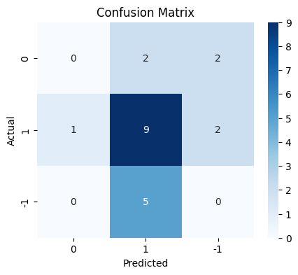

```python
plot_confusion_matrix(tuned_wv,X_val_st, y_val) #confusion matrix for the validation data
```

```python
#Calculating different metrics on training data
tuned_train_st=model_performance_classification_sklearn(tuned_wv,X_train_st, y_train)
print("Training performance:\n",tuned_train_st)
```

```
Training performance:
    Accuracy  Recall  Precision   F1
0       1.0     1.0        1.0  1.0
```

```python
#Calculating different metrics on validation data
tuned_val_st = model_performance_classification_sklearn(tuned_wv,X_val_st, y_val)
print("Validation performance:\n",tuned_val_st)
```

```
Validation performance:
    Accuracy    Recall  Precision        F1
0  0.428571  0.428571   0.321429  0.367347
```

### Model Performance Summary and Final Model Selection

```python
#training performance comparison

models_train_comp_df = pd.concat(
    [base_train_wv.T,
     base_train_gl.T,
     base_train_st.T,
     tuned_train_wv.T,
     tuned_train_gl.T,
     tuned_train_st.T,
    ],axis=1
)

models_train_comp_df.columns = [
    "Base Model (Word2Vec)",
    "Base Model (GloVe)",
    "Base Model (Sentence Transformer)",
    "Tuned Model (Word2Vec)",
    "Tuned Model (GloVe)",
    "Tuned Model (Sentence Transformer)",
]

print("Training performance comparison:")
models_train_comp_df
```

```
Training performance comparison:
```

|  | Base Model (Word2Vec) | Base Model (GloVe) | Base Model (Sentence Transformer) | Tuned Model (Word2Vec) | Tuned Model (GloVe) | Tuned Model (Sentence Transformer) |
| --- | --- | --- | --- | --- | --- | --- |
| Accuracy | 1.0 | 1.0 | 1.0 | 1.0 | 1.0 | 1.0 |
| Recall | 1.0 | 1.0 | 1.0 | 1.0 | 1.0 | 1.0 |
| Precision | 1.0 | 1.0 | 1.0 | 1.0 | 1.0 | 1.0 |
| F1 | 1.0 | 1.0 | 1.0 | 1.0 | 1.0 | 1.0 |

```python
#validation performance comparison

models_val_comp_df = pd.concat(
    [base_val_wv.T,
     base_val_gl.T,
     base_val_st.T,
     tuned_val_wv.T,
     tuned_val_gl.T,
     tuned_val_st.T,
     ],axis=1
)

models_val_comp_df.columns = [
    "Base Model (Word2Vec)",
    "Base Model (GloVe)",
    "Base Model (Sentence Transformer)",
    "Tuned Model (Word2Vec)",
    "Tuned Model (GloVe)",
    "Tuned Model (Sentence Transformer)",
]

print("Validation performance comparison:")
models_val_comp_df
```

```
Validation performance comparison:
```

|  | Base Model (Word2Vec) | Base Model (GloVe) | Base Model (Sentence Transformer) | Tuned Model (Word2Vec) | Tuned Model (GloVe) | Tuned Model (Sentence Transformer) |
| --- | --- | --- | --- | --- | --- | --- |
| Accuracy | 0.428571 | 0.380952 | 0.428571 | 0.476190 | 0.380952 | 0.428571 |
| Recall | 0.428571 | 0.380952 | 0.428571 | 0.476190 | 0.380952 | 0.428571 |
| Precision | 0.285714 | 0.326531 | 0.321429 | 0.300752 | 0.326531 | 0.321429 |
| F1 | 0.342857 | 0.351648 | 0.367347 | 0.368664 | 0.351648 | 0.367347 |

### Model Performance Check on Test Data

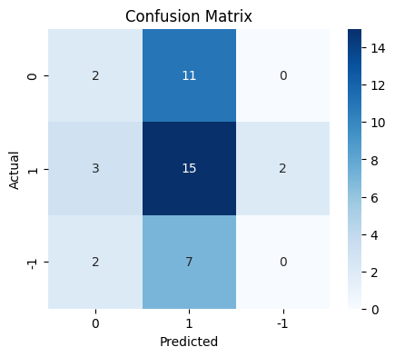

```python
plot_confusion_matrix(tuned_wv,X_test_st,y_test) #Complete the code to plot the confusion matrix for the final model and test data
```

```python
#Calculating different metrics on training data
final_model_test = model_performance_classification_sklearn(tuned_wv,X_test_st,y_test) #Complete the code to compute the final model's performance for the test data
print("Test performance for the final model:\n",final_model_test)
```

```
Test performance for the final model:
    Accuracy    Recall  Precision        F1
0  0.404762  0.404762   0.304886  0.331447
```

## **Weekly News Summarization**

**Important Note**: It is recommended to run this section of the project independently from the previous sections in order to avoid runtime crashes due to RAM overload.

#### Installing and Importing the necessary libraries

```python
# Installation for GPU llama-cpp-python
# uncomment and run the following code in case GPU is being used
!CMAKE_ARGS="-DLLAMA_CUBLAS=on" FORCE_CMAKE=1 pip install llama-cpp-python==0.2.45 --force-reinstall --no-cache-dir -q

# Installation for CPU llama-cpp-python
# uncomment and run the following code in case GPU is not being used
#!CMAKE_ARGS="-DLLAMA_CUBLAS=off" FORCE_CMAKE=1 pip install llama-cpp-python -q
```

[output not shown]

```python
# For downloading the models from HF Hub
!pip install huggingface_hub==0.20.3 -q
```

[output not shown]

```python
# Function to download the model from the Hugging Face model hub
from huggingface_hub import hf_hub_download

# Importing the Llama class from the llama_cpp module
from llama_cpp import Llama

# Importing the library for data manipulation
import pandas as pd

from tqdm import tqdm # For progress bar related functionalities
tqdm.pandas()
```

#### Loading the data

```python
stock_news = pd.read_csv("/content/drive/MyDrive/finalProject/stock_news.csv")
```

```python
data = stock_news.copy()
```

#### Loading the model

```python
model_name_or_path = "TheBloke/Mistral-7B-Instruct-v0.2-GGUF"
model_basename = "mistral-7b-instruct-v0.2.Q6_K.gguf"


model_path = hf_hub_download(
    repo_id=model_name_or_path, # Complete the code to mention the repo_id
    filename=model_basename # Complete the code to mention the filename
)
```

```python
#uncomment the below snippet of code if the runtime is connected to GPU.
llm = Llama(
    model_path=model_path, # Path to the model
    n_gpu_layers=100, #Number of layers transferred to GPU
    n_ctx=4500, #Context window
)
```

[output not shown]

[output cut: 33 more lines]

[output not shown]

#### Aggregating the data weekly

```python
data["Date"] = pd.to_datetime(data['Date'])  # Convert the 'Date' column to datetime format.
```

```python
# Group the data by week using the 'Date' column.
weekly_grouped = data.groupby(pd.Grouper(key='Date', freq='W'))
```

```python
weekly_grouped = weekly_grouped.agg(
    {
        'News': lambda x: ' || '.join(x)  # Join the news values with ' || ' separator.
    }
).reset_index()

print(weekly_grouped.shape)
```

```
(18, 2)
```

```python
weekly_grouped
```

|  | Date | News |
| --- | --- | --- |
| 0 | 2019-01-06 | The tech sector experienced a significant dec... |
| 1 | 2019-01-13 | Sprint and Samsung plan to release 5G smartph... |
| 2 | 2019-01-20 | The U.S. stock market declined on Monday as c... |
| 3 | 2019-01-27 | The Swiss National Bank (SNB) governor, Andre... |
| 4 | 2019-02-03 | Caterpillar Inc reported lower-than-expected ... |
| 5 | 2019-02-10 | The Dow Jones Industrial Average, S&P 500, an... |
| 6 | 2019-02-17 | This week, the European Union's second highes... |
| 7 | 2019-02-24 | This news article discusses progress towards ... |
| 8 | 2019-03-03 | The Dow Jones Industrial Average and other ma... |
| 9 | 2019-03-10 | Spotify, the world's largest paid music strea... |
| 10 | 2019-03-17 | The United States opposes France's digital se... |
| 11 | 2019-03-24 | Facebook's stock price dropped more than 3% o... |
| 12 | 2019-03-31 | This news article reports that the S&P 500 In... |
| 13 | 2019-04-07 | Apple and other consumer brands, including LV... |
| 14 | 2019-04-14 | In March, mobile phone shipments to China dro... |
| 15 | 2019-04-21 | The chairman of Taiwan's Foxconn, Terry Gou, ... |
| 16 | 2019-04-28 | Taiwan's export orders continued to decline f... |
| 17 | 2019-05-05 | Spotify reported better-than-expected Q1 reve... |

```python
# creating a copy of the data
data_1 = weekly_grouped.copy()
```

#### Summarization

**Note**:

- The model is expected to summarize the news from the week by identifying the top three positive and negative events that are most likely to impact the price of the stock.
- As an output, the model is expected to return a JSON containing two keys, one for Positive Events and one for Negative Events.

For the project, we need to define the prompt to be fed to the LLM to help it understand the task to perform. The following should be the components of the prompt:

1. **Role**: Specifies the role the LLM will be taking up to perform the specified task, along with any specific details regarding the role
   - **Example**: `You are an expert data analyst specializing in news content analysis.`
2. **Task**: Specifies the task to be performed and outlines what needs to be accomplished, clearly defining the objective
   - **Example**: `Analyze the provided news headline and return the main topics contained within it.`
3. **Instructions**: Provides detailed guidelines on how to perform the task, which includes steps, rules, and criteria to ensure the task is executed correctly
   - **Example**:

```
Instructions:
1. Read the news headline carefully.
2. Identify the main subjects or entities mentioned in the headline.
3. Determine the key events or actions described in the headline.
4. Extract relevant keywords that represent the topics.
5. List the topics in a concise manner.
```

1. **Output Format**: Specifies the format in which the final response should be structured, ensuring consistency and clarity in the generated output
   - **Example**: `Return the output in JSON format with keys as the topic number and values as the actual topic.`

**Full Prompt Example**:

```
You are an expert data analyst specializing in news content analysis.

Task: Analyze the provided news headline and return the main topics contained within it.

Instructions:
1. Read the news headline carefully.
2. Identify the main subjects or entities mentioned in the headline.
3. Determine the key events or actions described in the headline.
4. Extract relevant keywords that represent the topics.
5. List the topics in a concise manner.

Return the output in JSON format with keys as the topic number and values as the actual topic.
```

**Sample Output**:

`{"1": "Politics", "2": "Economy", "3": "Health" }`

##### Utility Functions

```python
# defining a function to parse the JSON output from the model
def extract_json_data(json_str):
    import json
    try:
        # Find the indices of the opening and closing curly braces
        json_start = json_str.find('{')
        json_end = json_str.rfind('}')

        if json_start != -1 and json_end != -1:
            extracted_category = json_str[json_start:json_end + 1]  # Extract the JSON object
            data_dict = json.loads(extracted_category)
            return data_dict
        else:
            print(f"Warning: JSON object not found in response: {json_str}")
            return {}
    except json.JSONDecodeError as e:
        print(f"Error parsing JSON: {e}")
        return {}
```

##### Defining the response function

```python
#Defining the response function
def response_mistral_1(prompt, news):
    model_output = llm(
      f"""
      [INST]
      {prompt}
      News Articles: {news}
      [/INST]
      """,
      max_tokens=1024, #set the maximum number of tokens the model should generate for this task.
      temperature=0, #set the value for temperature.
      top_p=0.95, #set the value for top_p
      top_k=50, #set the value for top_k
      echo=False,
    )

    final_output = model_output["choices"][0]["text"]

    return final_output
```

##### Checking the model output on a sample

**Note**: Use this section to test out the prompt with one instance before using it for the entire weekly data.

```python
news = data_1.loc[0, 'News']
```

```python
print(len(news.split(' ')))
news
```

```
2611
```

```
' The tech sector experienced a significant decline in the aftermarket following Apple\'s Q1 revenue warning. Notable suppliers, including Skyworks, Broadcom, Lumentum, Qorvo, and TSMC, saw their stocks drop in response to Apple\'s downward revision of its revenue expectations for the quarter, previ…
```

```python
#Complete the code to define the prompt for this task
prompt = """
You are an expert data analyst specializing in news content analysis.

Task: Analyze the provided news headline and return the main topics contained within it.

Instructions:
1. Read the news headline carefully.
2. Identify the main subjects or entities mentioned in the headline.
3. Determine the key events or actions described in the headline.
4. Extract relevant keywords that represent the topics.
5. List the topics in a concise manner.

Return the output in JSON format with keys as the topic number and values as the actual topic.
"""
```

```python
%%time
summary = response_mistral_1(prompt, news)
print(summary)
```

[output not shown]

```
 [
        {
          "topic_num": 1,
          "topic": "Apple's Q1 revenue warning and its impact on tech stocks"
        },
        {
          "topic_num": 2,
          "topic": "Global economic concerns following weak economic data from China and Europe"
        },
        {
          "topic_num": 3,
          "topic": "Impact of Apple's revenue warning on currency markets (USD JPY, Japanese yen)"
        },
        {
          "topic_num": 4,
          "topic": "Apple's revenue warning and its impact on U.S. Treasury yields"
        },
        {
          "topic_num": 5,
          "topic": "Apple's revenue warning and its impact on gold prices"
        },
        {
          "topic_num": 6,
          "topic": "Impact of Apple's revenue warning on other tech companies (Sesen Bio, Prana Biotechnology, Mellanox Technologies)"
        },
        {
          "topic_num": 7,
          "topic": "Impact of Apple's revenue warning on airline industry (Delta Air Lines)"
        },
        {
          "topic_num": 8,
          "topic": "Impact of Apple's revenue warning on interest rates"
        },
        {
          "topic_num": 9,
          "topic": "Impact of Apple's revenue warning on trade talks between US and China"
        },
        {
          "topic_num": 10,
          "topic": "Impact of Apple's revenue warning on oil prices"
```

[output cut: 13 more lines]

```
        {
          "topic_num": 14,
          "topic": "Impact of Apple's revenue warning on Amazon"
        },
        {
          "topic_num": 15,
          "topic": "Legal issues related to Broadcom's acquisition of Emulex"
        },
        {
          "topic_num": 16,
          "topic": "Chinese central bank's efforts to boost lending"
        }
      ]
CPU times: user 29.6 s, sys: 1.24 s, total: 30.8 s
Wall time: 32.2 s
```

##### Checking the model output on the weekly data

```python
%%time
data_1['Key Events'] = data_1['News'].progress_apply(lambda x: response_mistral_1(prompt,x))
```

[output not shown]

[output cut: 52 more lines]

[output not shown]

```
CPU times: user 6min 51s, sys: 7.44 s, total: 6min 58s
Wall time: 7min 20s
```

```python
data_1["Key Events"].head()
```

|  | Key Events |
| --- | --- |
| 0 | [\n {\n "topic_num": 1,\n ... |
| 1 | {\n "1": "5G smartphones release in n... |
| 2 | {\n "1": "U.S. stock market decline",... |
| 3 | {\n "1": "Swiss National Bank (SNB) a... |
| 4 | {\n "1": "Caterpillar Inc's lower-th... |

**dtype:** object

##### Formatting the model output

```python
data_1['model_response_parsed'] = data_1['Key Events'].apply(extract_json_data)
data_1.head()
```

[output not shown]

[output cut: 26 more lines]

[output not shown]

|  | Date | News | Key Events | model_response_parsed |
| --- | --- | --- | --- | --- |
| 0 | 2019-01-06 | The tech sector experienced a significant dec... | [\n {\n "topic_num": 1,\n ... | {} |
| 1 | 2019-01-13 | Sprint and Samsung plan to release 5G smartph... | {\n "1": "5G smartphones release in n... | {'1': '5G smartphones release in nine U.S. cit... |
| 2 | 2019-01-20 | The U.S. stock market declined on Monday as c... | {\n "1": "U.S. stock market decline",... | {'1': 'U.S. stock market decline', '2': 'Globa... |
| 3 | 2019-01-27 | The Swiss National Bank (SNB) governor, Andre... | {\n "1": "Swiss National Bank (SNB) a... | {'1': 'Swiss National Bank (SNB) and negative ... |
| 4 | 2019-02-03 | Caterpillar Inc reported lower-than-expected ... | {\n "1": "Caterpillar Inc's lower-th... | {'1': 'Caterpillar Inc's lower-than-expected e... |

```python
model_response_parsed = pd.json_normalize(data_1['model_response_parsed'])
model_response_parsed.head()
```

|  | 1 | 2 | 3 | 4 | 5 | 6 | 7 | 8 | 9 | 10 | ... | topic_9 | topic_10 | topic_11 | topic_12 | topic_13 | topic_14 | topic_15 | topic_16 | topic_17 | topic_18 |
| --- | --- | --- | --- | --- | --- | --- | --- | --- | --- | --- | --- | --- | --- | --- | --- | --- | --- | --- | --- | --- | --- |
| 0 | NaN | NaN | NaN | NaN | NaN | NaN | NaN | NaN | NaN | NaN | ... | NaN | NaN | NaN | NaN | NaN | NaN | NaN | NaN | NaN | NaN |
| 1 | 5G smartphones release in nine U.S. cities | AMS developing new 3D facial recognition featu... | Vivendi's Universal Music Group valuation incr... | Amazon stock prediction to surge by over 20% | AMS partnering with Chinese software maker Fac... | Geely forecasting flat sales for 2019 | China making efforts to address U.S. concerns ... | Progress in U.S.-China trade talks | Qualcomm expanding lineup of car computing chips | Mercedes Benz top selling premium automotive b... | ... | NaN | NaN | NaN | NaN | NaN | NaN | NaN | NaN | NaN | NaN |
| 2 | U.S. stock market decline | Global economic slowdown concerns | Chinese exports and imports drop | Tech stocks losses | Philadelphia SE Semiconductor Index decline | European stock market rally halt | Luxury retailers stock decline | Chinese auto market contraction | US-China trade war impact on Chinese auto market | Dialog Semiconductor revenue report | ... | NaN | NaN | NaN | NaN | NaN | NaN | NaN | NaN | NaN | NaN |
| 3 | Swiss National Bank (SNB) and negative interes... | Stock market losses (Dow, S&P 500, Nasdaq) | IBM's better-than-expected earnings and revenue | Huawei's new Honor View20 smartphone launch | Foxconn recruitment drive and potential layoffs | Amazon's direct fulfillment and delivery netwo... | Tesla's potential battery supplier negotiation... | TomTom's sale of fleet management business to ... | Japan Display's potential funding from Taiwan'... | White House-China trade negotiations and intel... | ... | NaN | NaN | NaN | NaN | NaN | NaN | NaN | NaN | NaN | NaN |
| 4 | Caterpillar Inc's lower-than-expected earnings... | Apple's spending over $60 billion with US comp... | Apple's expected lower-than-projected fiscal f... | China's smartphone shipments declining YoY wit... | Gold reaching a seven-month high due to upcomi... | CVS Health's new health app for Apple Watches ... | Apple's FaceTime bug that lets users hear audi... | Apple, Aetna, and CVS collaborating on a new h... | Corning reporting higher-than-expected revenue... | Gold's price increase driven by anticipation f... | ... | NaN | NaN | NaN | NaN | NaN | NaN | NaN | NaN | NaN | NaN |

5 rows × 51 columns

```python
final_output = pd.concat([data_1.reset_index(drop=True),model_response_parsed],axis=1)
final_output.drop(['Key Events','model_response_parsed'], axis=1, inplace=True)

# Instead of assigning 4 column names to a DataFrame with 53 columns,
# create a list of column names with the correct length (53)
# Below is one way to do it. You should modify it according to your desired column names.
current_columns = final_output.columns.tolist()  # Get the current column names
new_columns = ['Week End Date', 'News', 'Week Positive Events', 'Week Negative Events'] + current_columns[4:]
# Replace the first two with desired names, keep the rest

#Now assign this list, which has length 53, to final_output.columns
final_output.columns = new_columns

final_output.head()
```

[output not shown]

5 rows × 53 columns